# Optimal Treatment Analysis

## Outcome Variable

**Outcome Variable:** ever_wasted

## Predictor Variables

**Intervention Variable:** nrooms

**Adjustment Set:**

- arm
- sex
- W_mage
- meducyrs
- feducyrs
- hhwealth_quart
- hfoodsec
- W_mhtcm
- W_nchldlt5
- W_parity
- impfloor
- impsan
- safeh20
- delta_W_mage
- delta_meducyrs
- delta_feducyrs
- delta_hhwealth_quart
- delta_hfoodsec
- delta_W_mhtcm
- delta_W_nchldlt5
- delta_W_parity
- delta_impfloor
- delta_impsan
- delta_safeh20

## Stratifying Variables

The analysis was stratified on these variable(s):

- agecat
- studyid
- country

## Data Summary

| agecat | studyid | country | nrooms | ever_wasted | n_cell | n |
| --- | --- | --- | --- | --- | --- | --- |
| 0-24 months | ki0047075b-MAL-ED | BANGLADESH | 4+ | 0 | 9 | 242 |
| 0-24 months | ki0047075b-MAL-ED | BANGLADESH | 4+ | 1 | 3 | 242 |
| 0-24 months | ki0047075b-MAL-ED | BANGLADESH | 1 | 0 | 92 | 242 |
| 0-24 months | ki0047075b-MAL-ED | BANGLADESH | 1 | 1 | 60 | 242 |
| 0-24 months | ki0047075b-MAL-ED | BANGLADESH | 2 | 0 | 37 | 242 |
| 0-24 months | ki0047075b-MAL-ED | BANGLADESH | 2 | 1 | 13 | 242 |
| 0-24 months | ki0047075b-MAL-ED | BANGLADESH | 3 | 0 | 20 | 242 |
| 0-24 months | ki0047075b-MAL-ED | BANGLADESH | 3 | 1 | 8 | 242 |
| 0-24 months | ki0047075b-MAL-ED | BRAZIL | 4+ | 0 | 114 | 210 |
| 0-24 months | ki0047075b-MAL-ED | BRAZIL | 4+ | 1 | 13 | 210 |
| 0-24 months | ki0047075b-MAL-ED | BRAZIL | 1 | 0 | 4 | 210 |
| 0-24 months | ki0047075b-MAL-ED | BRAZIL | 1 | 1 | 0 | 210 |
| 0-24 months | ki0047075b-MAL-ED | BRAZIL | 2 | 0 | 18 | 210 |
| 0-24 months | ki0047075b-MAL-ED | BRAZIL | 2 | 1 | 2 | 210 |
| 0-24 months | ki0047075b-MAL-ED | BRAZIL | 3 | 0 | 55 | 210 |
| 0-24 months | ki0047075b-MAL-ED | BRAZIL | 3 | 1 | 4 | 210 |
| 0-24 months | ki0047075b-MAL-ED | INDIA | 4+ | 0 | 16 | 235 |
| 0-24 months | ki0047075b-MAL-ED | INDIA | 4+ | 1 | 9 | 235 |
| 0-24 months | ki0047075b-MAL-ED | INDIA | 1 | 0 | 43 | 235 |
| 0-24 months | ki0047075b-MAL-ED | INDIA | 1 | 1 | 41 | 235 |
| 0-24 months | ki0047075b-MAL-ED | INDIA | 2 | 0 | 38 | 235 |
| 0-24 months | ki0047075b-MAL-ED | INDIA | 2 | 1 | 40 | 235 |
| 0-24 months | ki0047075b-MAL-ED | INDIA | 3 | 0 | 25 | 235 |
| 0-24 months | ki0047075b-MAL-ED | INDIA | 3 | 1 | 23 | 235 |
| 0-24 months | ki0047075b-MAL-ED | NEPAL | 4+ | 0 | 95 | 236 |
| 0-24 months | ki0047075b-MAL-ED | NEPAL | 4+ | 1 | 36 | 236 |
| 0-24 months | ki0047075b-MAL-ED | NEPAL | 1 | 0 | 31 | 236 |
| 0-24 months | ki0047075b-MAL-ED | NEPAL | 1 | 1 | 21 | 236 |
| 0-24 months | ki0047075b-MAL-ED | NEPAL | 2 | 0 | 26 | 236 |
| 0-24 months | ki0047075b-MAL-ED | NEPAL | 2 | 1 | 5 | 236 |

[output cut: 354 more lines]

The following strata were considered:

- agecat: 0-24 months, studyid: ki0047075b-MAL-ED, country: BANGLADESH
- agecat: 0-24 months, studyid: ki0047075b-MAL-ED, country: BRAZIL
- agecat: 0-24 months, studyid: ki0047075b-MAL-ED, country: INDIA
- agecat: 0-24 months, studyid: ki0047075b-MAL-ED, country: NEPAL
- agecat: 0-24 months, studyid: ki0047075b-MAL-ED, country: PERU
- agecat: 0-24 months, studyid: ki0047075b-MAL-ED, country: SOUTH AFRICA
- agecat: 0-24 months, studyid: ki0047075b-MAL-ED, country: TANZANIA, UNITED REPUBLIC OF
- agecat: 0-24 months, studyid: ki1000108-CMC-V-BCS-2002, country: INDIA
- agecat: 0-24 months, studyid: ki1000108-IRC, country: INDIA
- agecat: 0-24 months, studyid: ki1017093b-PROVIDE, country: BANGLADESH
- agecat: 0-24 months, studyid: ki1017093c-NIH-Crypto, country: BANGLADESH
- agecat: 0-24 months, studyid: ki1113344-GMS-Nepal, country: NEPAL
- agecat: 0-24 months, studyid: ki1114097-CONTENT, country: PERU
- agecat: 0-24 months, studyid: ki1135781-COHORTS, country: INDIA
- agecat: 0-24 months, studyid: kiGH5241-JiVitA-3, country: BANGLADESH
- agecat: 0-24 months, studyid: kiGH5241-JiVitA-4, country: BANGLADESH
- agecat: 0-6 months, studyid: ki0047075b-MAL-ED, country: BANGLADESH
- agecat: 0-6 months, studyid: ki0047075b-MAL-ED, country: BRAZIL
- agecat: 0-6 months, studyid: ki0047075b-MAL-ED, country: INDIA
- agecat: 0-6 months, studyid: ki0047075b-MAL-ED, country: NEPAL
- agecat: 0-6 months, studyid: ki0047075b-MAL-ED, country: PERU
- agecat: 0-6 months, studyid: ki0047075b-MAL-ED, country: SOUTH AFRICA
- agecat: 0-6 months, studyid: ki0047075b-MAL-ED, country: TANZANIA, UNITED REPUBLIC OF
- agecat: 0-6 months, studyid: ki1000108-CMC-V-BCS-2002, country: INDIA
- agecat: 0-6 months, studyid: ki1000108-IRC, country: INDIA
- agecat: 0-6 months, studyid: ki1017093b-PROVIDE, country: BANGLADESH
- agecat: 0-6 months, studyid: ki1017093c-NIH-Crypto, country: BANGLADESH
- agecat: 0-6 months, studyid: ki1113344-GMS-Nepal, country: NEPAL
- agecat: 0-6 months, studyid: ki1114097-CONTENT, country: PERU
- agecat: 0-6 months, studyid: ki1135781-COHORTS, country: INDIA
- agecat: 0-6 months, studyid: kiGH5241-JiVitA-3, country: BANGLADESH
- agecat: 0-6 months, studyid: kiGH5241-JiVitA-4, country: BANGLADESH
- agecat: 6-24 months, studyid: ki0047075b-MAL-ED, country: BANGLADESH
- agecat: 6-24 months, studyid: ki0047075b-MAL-ED, country: BRAZIL
- agecat: 6-24 months, studyid: ki0047075b-MAL-ED, country: INDIA
- agecat: 6-24 months, studyid: ki0047075b-MAL-ED, country: NEPAL
- agecat: 6-24 months, studyid: ki0047075b-MAL-ED, country: PERU
- agecat: 6-24 months, studyid: ki0047075b-MAL-ED, country: SOUTH AFRICA
- agecat: 6-24 months, studyid: ki0047075b-MAL-ED, country: TANZANIA, UNITED REPUBLIC OF
- agecat: 6-24 months, studyid: ki1000108-CMC-V-BCS-2002, country: INDIA
- agecat: 6-24 months, studyid: ki1000108-IRC, country: INDIA
- agecat: 6-24 months, studyid: ki1017093b-PROVIDE, country: BANGLADESH
- agecat: 6-24 months, studyid: ki1017093c-NIH-Crypto, country: BANGLADESH
- agecat: 6-24 months, studyid: ki1113344-GMS-Nepal, country: NEPAL
- agecat: 6-24 months, studyid: ki1114097-CONTENT, country: PERU
- agecat: 6-24 months, studyid: ki1135781-COHORTS, country: INDIA
- agecat: 6-24 months, studyid: kiGH5241-JiVitA-3, country: BANGLADESH
- agecat: 6-24 months, studyid: kiGH5241-JiVitA-4, country: BANGLADESH

### Dropped Strata

Some strata were dropped due to rare outcomes:

- agecat: 0-24 months, studyid: ki0047075b-MAL-ED, country: BANGLADESH
- agecat: 0-24 months, studyid: ki0047075b-MAL-ED, country: BRAZIL
- agecat: 0-24 months, studyid: ki0047075b-MAL-ED, country: PERU
- agecat: 0-24 months, studyid: ki0047075b-MAL-ED, country: SOUTH AFRICA
- agecat: 0-24 months, studyid: ki0047075b-MAL-ED, country: TANZANIA, UNITED REPUBLIC OF
- agecat: 0-24 months, studyid: ki1114097-CONTENT, country: PERU
- agecat: 0-6 months, studyid: ki0047075b-MAL-ED, country: BANGLADESH
- agecat: 0-6 months, studyid: ki0047075b-MAL-ED, country: BRAZIL
- agecat: 0-6 months, studyid: ki0047075b-MAL-ED, country: NEPAL
- agecat: 0-6 months, studyid: ki0047075b-MAL-ED, country: PERU
- agecat: 0-6 months, studyid: ki0047075b-MAL-ED, country: SOUTH AFRICA
- agecat: 0-6 months, studyid: ki0047075b-MAL-ED, country: TANZANIA, UNITED REPUBLIC OF
- agecat: 0-6 months, studyid: ki1000108-CMC-V-BCS-2002, country: INDIA
- agecat: 0-6 months, studyid: ki1114097-CONTENT, country: PERU
- agecat: 0-6 months, studyid: kiGH5241-JiVitA-4, country: BANGLADESH
- agecat: 6-24 months, studyid: ki0047075b-MAL-ED, country: BANGLADESH
- agecat: 6-24 months, studyid: ki0047075b-MAL-ED, country: BRAZIL
- agecat: 6-24 months, studyid: ki0047075b-MAL-ED, country: INDIA
- agecat: 6-24 months, studyid: ki0047075b-MAL-ED, country: NEPAL
- agecat: 6-24 months, studyid: ki0047075b-MAL-ED, country: PERU
- agecat: 6-24 months, studyid: ki0047075b-MAL-ED, country: SOUTH AFRICA
- agecat: 6-24 months, studyid: ki0047075b-MAL-ED, country: TANZANIA, UNITED REPUBLIC OF
- agecat: 6-24 months, studyid: ki1000108-CMC-V-BCS-2002, country: INDIA
- agecat: 6-24 months, studyid: ki1017093b-PROVIDE, country: BANGLADESH
- agecat: 6-24 months, studyid: ki1114097-CONTENT, country: PERU
- agecat: 6-24 months, studyid: ki1135781-COHORTS, country: INDIA

## Methods Detail

We’re interested in the causal parameters $E[Y_a]$ for all values of $a \in \mathcal{A}$. These parameters represent the mean outcome if, possibly contrary to fact, we intervened to set all units to have $A=a$. Under the randomization and positivity assumptions, these are identified by the statistical parameters $\psi_a=E_W[E_{Y|A,W}(Y|A=a,W)]$. In addition, we’re interested in the mean of $Y$, $E[Y]$ under no intervention (the observed mean). We will estimate these parameters by using SuperLearner to fit the relevant likelihood factors – $E_{Y|A,W}(Y|A=a,W)$ and $p(A=a|W)$, and then updating our likelihood fit using a joint TMLE.

For unadjusted analyses ($W=\{\}$), initial likelihoods were estimated using Lrnr_glm to estimate the simple $E(Y|A)$ and Lrnr_mean to estimate $p(A)$. For adjusted analyses, a small library containing Lrnr_glmnet, Lrnr_xgboost, and Lrnr_mean was used.

Having estimated these parameters, we will then use the delta method to estimate relative risks and attributable risks relative to a prespecified baseline level of $A$.

# Results Detail

## Results Plots

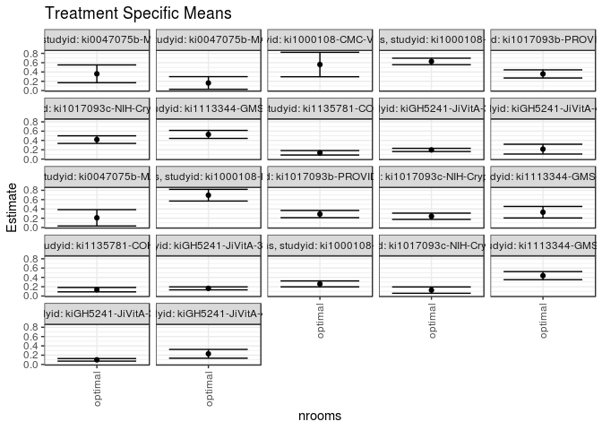

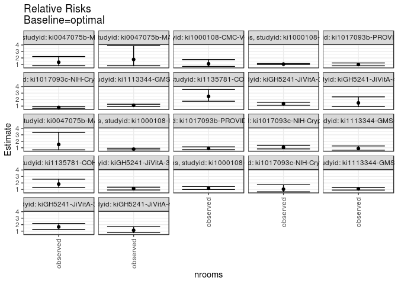

## Results Table

### Parameter: TSM

| agecat | studyid | country | intervention_level | baseline_level | estimate | ci_lower | ci_upper |
| --- | --- | --- | --- | --- | --- | --- | --- |
| 0-24 months | ki0047075b-MAL-ED | INDIA | optimal | NA | 0.3603290 | 0.1689282 | 0.5517297 |
| 0-24 months | ki0047075b-MAL-ED | NEPAL | optimal | NA | 0.1634646 | 0.0278034 | 0.2991257 |
| 0-24 months | ki1000108-CMC-V-BCS-2002 | INDIA | optimal | NA | 0.5599986 | 0.2968841 | 0.8231131 |
| 0-24 months | ki1000108-IRC | INDIA | optimal | NA | 0.6262386 | 0.5560427 | 0.6964345 |
| 0-24 months | ki1017093b-PROVIDE | BANGLADESH | optimal | NA | 0.3582224 | 0.2706576 | 0.4457872 |
| 0-24 months | ki1017093c-NIH-Crypto | BANGLADESH | optimal | NA | 0.4178863 | 0.3360910 | 0.4996816 |
| 0-24 months | ki1113344-GMS-Nepal | NEPAL | optimal | NA | 0.5295596 | 0.4435305 | 0.6155887 |
| 0-24 months | ki1135781-COHORTS | INDIA | optimal | NA | 0.1342403 | 0.0863816 | 0.1820989 |
| 0-24 months | kiGH5241-JiVitA-3 | BANGLADESH | optimal | NA | 0.1961861 | 0.1616247 | 0.2307475 |
| 0-24 months | kiGH5241-JiVitA-4 | BANGLADESH | optimal | NA | 0.2133188 | 0.1078269 | 0.3188107 |
| 0-6 months | ki0047075b-MAL-ED | INDIA | optimal | NA | 0.2087619 | 0.0335724 | 0.3839515 |
| 0-6 months | ki1000108-IRC | INDIA | optimal | NA | 0.6942846 | 0.5684913 | 0.8200778 |
| 0-6 months | ki1017093b-PROVIDE | BANGLADESH | optimal | NA | 0.2890371 | 0.2114192 | 0.3666550 |
| 0-6 months | ki1017093c-NIH-Crypto | BANGLADESH | optimal | NA | 0.2418713 | 0.1746776 | 0.3090650 |
| 0-6 months | ki1113344-GMS-Nepal | NEPAL | optimal | NA | 0.3287744 | 0.2048775 | 0.4526713 |
| 0-6 months | ki1135781-COHORTS | INDIA | optimal | NA | 0.1363335 | 0.0888185 | 0.1838486 |
| 0-6 months | kiGH5241-JiVitA-3 | BANGLADESH | optimal | NA | 0.1639316 | 0.1319578 | 0.1959054 |
| 6-24 months | ki1000108-IRC | INDIA | optimal | NA | 0.2600191 | 0.1965045 | 0.3235337 |
| 6-24 months | ki1017093c-NIH-Crypto | BANGLADESH | optimal | NA | 0.1264579 | 0.0586209 | 0.1942949 |
| 6-24 months | ki1113344-GMS-Nepal | NEPAL | optimal | NA | 0.4372044 | 0.3501800 | 0.5242289 |
| 6-24 months | kiGH5241-JiVitA-3 | BANGLADESH | optimal | NA | 0.0997140 | 0.0725368 | 0.1268913 |
| 6-24 months | kiGH5241-JiVitA-4 | BANGLADESH | optimal | NA | 0.2288256 | 0.1344123 | 0.3232389 |

### Parameter: E(Y)

| agecat | studyid | country | intervention_level | baseline_level | estimate | ci_lower | ci_upper |
| --- | --- | --- | --- | --- | --- | --- | --- |
| 0-24 months | ki0047075b-MAL-ED | INDIA | observed | NA | 0.4808511 | 0.4168346 | 0.5448675 |
| 0-24 months | ki0047075b-MAL-ED | NEPAL | observed | NA | 0.2881356 | 0.2302312 | 0.3460400 |
| 0-24 months | ki1000108-CMC-V-BCS-2002 | INDIA | observed | NA | 0.6139410 | 0.5644682 | 0.6634139 |
| 0-24 months | ki1000108-IRC | INDIA | observed | NA | 0.6568627 | 0.6107393 | 0.7029862 |
| 0-24 months | ki1017093b-PROVIDE | BANGLADESH | observed | NA | 0.3514286 | 0.3160364 | 0.3868207 |
| 0-24 months | ki1017093c-NIH-Crypto | BANGLADESH | observed | NA | 0.3311346 | 0.2976093 | 0.3646598 |
| 0-24 months | ki1113344-GMS-Nepal | NEPAL | observed | NA | 0.5913621 | 0.5520608 | 0.6306634 |
| 0-24 months | ki1135781-COHORTS | INDIA | observed | NA | 0.3354454 | 0.3228114 | 0.3480794 |
| 0-24 months | kiGH5241-JiVitA-3 | BANGLADESH | observed | NA | 0.2642176 | 0.2551208 | 0.2733143 |
| 0-24 months | kiGH5241-JiVitA-4 | BANGLADESH | observed | NA | 0.3184358 | 0.2901120 | 0.3467596 |
| 0-6 months | ki0047075b-MAL-ED | INDIA | observed | NA | 0.3148936 | 0.2553821 | 0.3744051 |
| 0-6 months | ki1000108-IRC | INDIA | observed | NA | 0.5441176 | 0.4957312 | 0.5925041 |
| 0-6 months | ki1017093b-PROVIDE | BANGLADESH | observed | NA | 0.2585714 | 0.2261125 | 0.2910304 |
| 0-6 months | ki1017093c-NIH-Crypto | BANGLADESH | observed | NA | 0.2585752 | 0.2273844 | 0.2897660 |
| 0-6 months | ki1113344-GMS-Nepal | NEPAL | observed | NA | 0.2956811 | 0.2591967 | 0.3321655 |
| 0-6 months | ki1135781-COHORTS | INDIA | observed | NA | 0.2494186 | 0.2376119 | 0.2612253 |
| 0-6 months | kiGH5241-JiVitA-3 | BANGLADESH | observed | NA | 0.1822500 | 0.1742334 | 0.1902667 |
| 6-24 months | ki1000108-IRC | INDIA | observed | NA | 0.3112745 | 0.2662918 | 0.3562572 |
| 6-24 months | ki1017093c-NIH-Crypto | BANGLADESH | observed | NA | 0.1315068 | 0.1069744 | 0.1560393 |
| 6-24 months | ki1113344-GMS-Nepal | NEPAL | observed | NA | 0.4728814 | 0.4325613 | 0.5132014 |
| 6-24 months | kiGH5241-JiVitA-3 | BANGLADESH | observed | NA | 0.1648532 | 0.1556668 | 0.1740396 |
| 6-24 months | kiGH5241-JiVitA-4 | BANGLADESH | observed | NA | 0.2573427 | 0.2311603 | 0.2835250 |

### Parameter: RR

| agecat | studyid | country | intervention_level | baseline_level | estimate | ci_lower | ci_upper |
| --- | --- | --- | --- | --- | --- | --- | --- |
| 0-24 months | ki0047075b-MAL-ED | INDIA | observed | optimal | 1.3344778 | 0.8048184 | 2.2127117 |
| 0-24 months | ki0047075b-MAL-ED | NEPAL | observed | optimal | 1.7626791 | 0.7963509 | 3.9015938 |
| 0-24 months | ki1000108-CMC-V-BCS-2002 | INDIA | observed | optimal | 1.0963260 | 0.6906258 | 1.7403501 |
| 0-24 months | ki1000108-IRC | INDIA | observed | optimal | 1.0489017 | 0.9663986 | 1.1384482 |
| 0-24 months | ki1017093b-PROVIDE | BANGLADESH | observed | optimal | 0.9810346 | 0.7856701 | 1.2249784 |
| 0-24 months | ki1017093c-NIH-Crypto | BANGLADESH | observed | optimal | 0.7924035 | 0.6590084 | 0.9528001 |
| 0-24 months | ki1113344-GMS-Nepal | NEPAL | observed | optimal | 1.1167056 | 0.9667309 | 1.2899467 |
| 0-24 months | ki1135781-COHORTS | INDIA | observed | optimal | 2.4988432 | 1.7525812 | 3.5628690 |
| 0-24 months | kiGH5241-JiVitA-3 | BANGLADESH | observed | optimal | 1.3467699 | 1.1320211 | 1.6022574 |
| 0-24 months | kiGH5241-JiVitA-4 | BANGLADESH | observed | optimal | 1.4927693 | 0.9191605 | 2.4243429 |
| 0-6 months | ki0047075b-MAL-ED | INDIA | observed | optimal | 1.5083863 | 0.6728479 | 3.3814912 |
| 0-6 months | ki1000108-IRC | INDIA | observed | optimal | 0.7837099 | 0.6632867 | 0.9259965 |
| 0-6 months | ki1017093b-PROVIDE | BANGLADESH | observed | optimal | 0.8945959 | 0.7027634 | 1.1387928 |
| 0-6 months | ki1017093c-NIH-Crypto | BANGLADESH | observed | optimal | 1.0690611 | 0.8262074 | 1.3832986 |
| 0-6 months | ki1113344-GMS-Nepal | NEPAL | observed | optimal | 0.8993433 | 0.6331650 | 1.2774211 |
| 0-6 months | ki1135781-COHORTS | INDIA | observed | optimal | 1.8294735 | 1.2934995 | 2.5875335 |
| 0-6 months | kiGH5241-JiVitA-3 | BANGLADESH | observed | optimal | 1.1117444 | 0.9172848 | 1.3474283 |
| 6-24 months | ki1000108-IRC | INDIA | observed | optimal | 1.1971217 | 0.9913579 | 1.4455934 |
| 6-24 months | ki1017093c-NIH-Crypto | BANGLADESH | observed | optimal | 1.0399259 | 0.6295734 | 1.7177439 |
| 6-24 months | ki1113344-GMS-Nepal | NEPAL | observed | optimal | 1.0816024 | 0.9064548 | 1.2905924 |
| 6-24 months | kiGH5241-JiVitA-3 | BANGLADESH | observed | optimal | 1.6532595 | 1.2598097 | 2.1695872 |
| 6-24 months | kiGH5241-JiVitA-4 | BANGLADESH | observed | optimal | 1.1246237 | 0.7533524 | 1.6788669 |

### Parameter: PAR

| agecat | studyid | country | intervention_level | baseline_level | estimate | ci_lower | ci_upper |
| --- | --- | --- | --- | --- | --- | --- | --- |
| 0-24 months | ki0047075b-MAL-ED | INDIA | optimal | NA | 0.1205221 | -0.0613555 | 0.3023997 |
| 0-24 months | ki0047075b-MAL-ED | NEPAL | optimal | NA | 0.1246710 | -0.0062836 | 0.2556256 |
| 0-24 months | ki1000108-CMC-V-BCS-2002 | INDIA | optimal | NA | 0.0539424 | -0.2048403 | 0.3127251 |
| 0-24 months | ki1000108-IRC | INDIA | optimal | NA | 0.0306241 | -0.0205514 | 0.0817996 |
| 0-24 months | ki1017093b-PROVIDE | BANGLADESH | optimal | NA | -0.0067938 | -0.0863520 | 0.0727643 |
| 0-24 months | ki1017093c-NIH-Crypto | BANGLADESH | optimal | NA | -0.0867517 | -0.1628857 | -0.0106177 |
| 0-24 months | ki1113344-GMS-Nepal | NEPAL | optimal | NA | 0.0618025 | -0.0144279 | 0.1380330 |
| 0-24 months | ki1135781-COHORTS | INDIA | optimal | NA | 0.2012051 | 0.1529424 | 0.2494678 |
| 0-24 months | kiGH5241-JiVitA-3 | BANGLADESH | optimal | NA | 0.0680314 | 0.0338094 | 0.1022535 |
| 0-24 months | kiGH5241-JiVitA-4 | BANGLADESH | optimal | NA | 0.1051170 | 0.0014122 | 0.2088218 |
| 0-6 months | ki0047075b-MAL-ED | INDIA | optimal | NA | 0.1061317 | -0.0624850 | 0.2747484 |
| 0-6 months | ki1000108-IRC | INDIA | optimal | NA | -0.1501669 | -0.2654529 | -0.0348809 |
| 0-6 months | ki1017093b-PROVIDE | BANGLADESH | optimal | NA | -0.0304657 | -0.1002105 | 0.0392792 |
| 0-6 months | ki1017093c-NIH-Crypto | BANGLADESH | optimal | NA | 0.0167039 | -0.0457788 | 0.0791866 |
| 0-6 months | ki1113344-GMS-Nepal | NEPAL | optimal | NA | -0.0330933 | -0.1487146 | 0.0825279 |
| 0-6 months | ki1135781-COHORTS | INDIA | optimal | NA | 0.1130851 | 0.0653640 | 0.1608061 |
| 0-6 months | kiGH5241-JiVitA-3 | BANGLADESH | optimal | NA | 0.0183184 | -0.0132515 | 0.0498884 |
| 6-24 months | ki1000108-IRC | INDIA | optimal | NA | 0.0512554 | 0.0020934 | 0.1004175 |
| 6-24 months | ki1017093c-NIH-Crypto | BANGLADESH | optimal | NA | 0.0050489 | -0.0584170 | 0.0685148 |
| 6-24 months | ki1113344-GMS-Nepal | NEPAL | optimal | NA | 0.0356769 | -0.0415032 | 0.1128570 |
| 6-24 months | kiGH5241-JiVitA-3 | BANGLADESH | optimal | NA | 0.0651391 | 0.0374785 | 0.0927998 |
| 6-24 months | kiGH5241-JiVitA-4 | BANGLADESH | optimal | NA | 0.0285171 | -0.0632356 | 0.1202698 |

### Parameter: PAF

| agecat | studyid | country | intervention_level | baseline_level | estimate | ci_lower | ci_upper |
| --- | --- | --- | --- | --- | --- | --- | --- |
| 0-24 months | ki0047075b-MAL-ED | INDIA | optimal | NA | 0.2506432 | -0.2425163 | 0.5480658 |
| 0-24 months | ki0047075b-MAL-ED | NEPAL | optimal | NA | 0.4326818 | -0.2557278 | 0.7436945 |
| 0-24 months | ki1000108-CMC-V-BCS-2002 | INDIA | optimal | NA | 0.0878625 | -0.4479621 | 0.4254030 |
| 0-24 months | ki1000108-IRC | INDIA | optimal | NA | 0.0466218 | -0.0347698 | 0.1216113 |
| 0-24 months | ki1017093b-PROVIDE | BANGLADESH | optimal | NA | -0.0193320 | -0.2727989 | 0.1836591 |
| 0-24 months | ki1017093c-NIH-Crypto | BANGLADESH | optimal | NA | -0.2619833 | -0.5174313 | -0.0495381 |
| 0-24 months | ki1113344-GMS-Nepal | NEPAL | optimal | NA | 0.1045088 | -0.0344141 | 0.2247742 |
| 0-24 months | ki1135781-COHORTS | INDIA | optimal | NA | 0.5998148 | 0.4294130 | 0.7193273 |
| 0-24 months | kiGH5241-JiVitA-3 | BANGLADESH | optimal | NA | 0.2574827 | 0.1166242 | 0.3758806 |
| 0-24 months | kiGH5241-JiVitA-4 | BANGLADESH | optimal | NA | 0.3301041 | -0.0879492 | 0.5875171 |
| 0-6 months | ki0047075b-MAL-ED | INDIA | optimal | NA | 0.3370398 | -0.4862200 | 0.7042725 |
| 0-6 months | ki1000108-IRC | INDIA | optimal | NA | -0.2759824 | -0.5076437 | -0.0799177 |
| 0-6 months | ki1017093b-PROVIDE | BANGLADESH | optimal | NA | -0.1178231 | -0.4229540 | 0.1218771 |
| 0-6 months | ki1017093c-NIH-Crypto | BANGLADESH | optimal | NA | 0.0645998 | -0.2103498 | 0.2770903 |
| 0-6 months | ki1113344-GMS-Nepal | NEPAL | optimal | NA | -0.1119224 | -0.5793671 | 0.2171728 |
| 0-6 months | ki1135781-COHORTS | INDIA | optimal | NA | 0.4533947 | 0.2269035 | 0.6135316 |
| 0-6 months | kiGH5241-JiVitA-3 | BANGLADESH | optimal | NA | 0.1005127 | -0.0901739 | 0.2578455 |
| 6-24 months | ki1000108-IRC | INDIA | optimal | NA | 0.1646631 | -0.0087174 | 0.3082426 |
| 6-24 months | ki1017093c-NIH-Crypto | BANGLADESH | optimal | NA | 0.0383930 | -0.5883771 | 0.4178410 |
| 6-24 months | ki1113344-GMS-Nepal | NEPAL | optimal | NA | 0.0754458 | -0.1031990 | 0.2251620 |
| 6-24 months | kiGH5241-JiVitA-3 | BANGLADESH | optimal | NA | 0.3951343 | 0.2062293 | 0.5390828 |
| 6-24 months | kiGH5241-JiVitA-4 | BANGLADESH | optimal | NA | 0.1108137 | -0.3273999 | 0.4043602 |